# Review of our PI2 Project : Implementing diffusion indexes in time of COVID

A diffusion index refers to the common tendency within a group of numbers or statistics. In the stock market, a diffusion index refers to whether more stocks are declining or falling within an index like the CAC40 in France or the S&P 500 in the USA.

### The goal of our project

The aim at the beginning of this project was to use a considerable number of available economic time series over the short period interested by the COVID pandemics and use diffusion indexes to improve forecasting.

But at the beginning we weren't expecting a second wave. So our project is still available through today's data.

The main purpose was to make prediction using diffusion indexes and show the results on an app or a website.

This page shows how we proceed to make prediction. Moroever you can navigate through the website to see the predictions and the other features.

### The method we use

Here we are using the Yahoo Finance API in order to get the stock price from CAC40 companies.

### Data processing

Let's see the evolution of the CAC40 index through since the beginning of COVID. We are going to predict how it will evolve in the next few days. You'll see next the code for the data processing (different dataframe that we are going to use). Especially the next explaination will be for the train test dataset.

```python
last_date = '2021-03-29'

# Create CAC40 stocks dataFrames
tickers_cac40_dict = tickers_cac40_dict_2
df_prices_returns = create_stocks_df(tickers_cac40_dict, last_date)
df_stocks_prices = df_prices_returns[0]
df_stocks_returns = df_prices_returns[1]

# Create CAC40 index dataFrames
df_index_value = df_stocks_prices['^FCHI']
df_index_returns = df_stocks_returns['^FCHI']

del df_stocks_prices['^FCHI']
del df_stocks_returns['^FCHI']

# ----- Training set
df_stocks_prices_train = df_stocks_prices[:'2021-03-21']
df_stocks_returns_train = df_stocks_returns[:'2021-03-21']

df_index_value_train = df_index_value[:'2021-03-21']
df_index_returns_train = df_index_returns[:'2021-03-21']

# ----- Test set
df_stocks_prices_test = df_stocks_prices['2021-03-22':]
df_stocks_returns_test = df_stocks_returns['2021-03-22':]

df_index_value_test = df_index_value['2021-03-22':]
df_index_returns_test = df_index_returns['2021-03-22':]
```

```
[*********************100%***********************]  41 of 41 completed
```

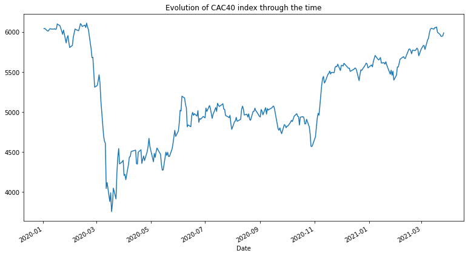

```python
plt.rcParams["figure.figsize"]=13,7
df_index_value.plot();
plt.title("Evolution of CAC40 index through the time");
plt.plot();
```

### Reduction of dataset dimension

The main problem in diffusion indexes is the amount of data. In fact, it is sometimes difficult to study diffusion indexes when there is noise or when time series that are less important than others.

So here we are using Principal Components Analysis to select the component that we are interesting to.

### First method : select components that correspond to 95% of explained variance

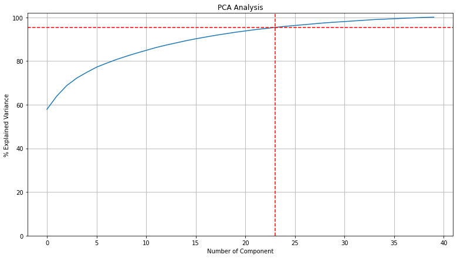

```python
pca = decomposition.PCA(n_components = 40).fit(df_stocks_returns_train)

# Select_component, fonction which compute the number of component we need to explained 95% of the information
nb_component = select_component(pca, 95)


# Plot explained variance
plot_explained_var(pca, nb_component)
```

##### Second method : Marchenko Pastur

We suppose in this section that our dataset contains noise. We are going through this section use the work of Vladimir MARCHENKO and Leonid PASTUR about random matrix theory.

Basically, the cov matrix contains noise and it is necessary to separate them from each other to obtain more realistic results. We are going here to create a model for the distribution of eigen value. Therefore we are going to select only eigenvalue which are inside the distribution.

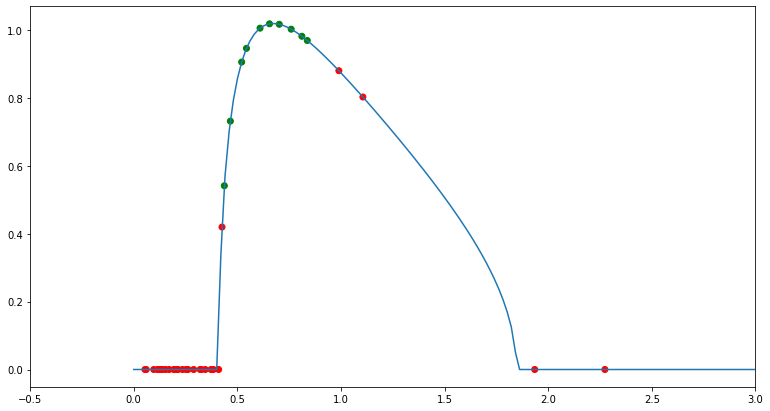

```python
# Correlation matrix
cor_matrix = df_stocks_returns_train.interpolate().corr()

# M : number of line
# N : number of column
M, N = df_stocks_returns_train.shape
Q = M/N


# Eigen value and eigen vector of correlation matrix
eigenval, eigenvec = LA.eig(cor_matrix)


# Variance of the eigenvalue
sigma = np.var(eigenval)

roo = []
col = []
for i in range(len(eigenval)):
    if eigenval[i] < marchenko_pastur_pdf1(eigenval[i], Q):
        roo.append(eigenvec[i])
        col.append('g')
    else:
        col.append('r')

x = np.linspace(0.0001, 20, 1000);

plt.plot(x, marchenko_pastur_pdf1(x, Q))
plt.scatter(eigenval, marchenko_pastur_pdf1(eigenval, Q), c=col)
plt.xlim(-0.5,3);
```

We are going here in order to simlify the comprehension use only the 5 first components. It'll be easier to understand the next part with less information.

```python
array_of_principal_components_train = pca.transform(df_stocks_returns_train)[:, :5]
df_of_principal_components_train = pd.DataFrame(array_of_principal_components_train)
df_of_principal_components_train
```

|  | 0 | 1 | 2 | 3 | 4 |
| --- | --- | --- | --- | --- | --- |
| 0 | 0.023448 | 0.001225 | -0.019701 | -0.011624 | 0.029318 |
| 1 | 0.044787 | 0.007531 | 0.012978 | 0.012983 | 0.012765 |
| 2 | -0.030249 | -0.003057 | 0.013738 | -0.006907 | -0.028480 |
| 3 | -0.013645 | -0.026748 | -0.009551 | 0.018624 | -0.002673 |
| 4 | -0.000090 | -0.023772 | -0.013887 | -0.003750 | 0.006900 |
| ... | ... | ... | ... | ... | ... |
| 306 | 0.016198 | -0.010807 | -0.015608 | -0.007864 | 0.012910 |
| 307 | -0.013921 | 0.016940 | -0.043637 | -0.031953 | 0.008763 |
| 308 | 0.006865 | 0.016671 | 0.046060 | 0.017510 | 0.001490 |
| 309 | -0.025263 | -0.006801 | 0.045885 | 0.049816 | -0.021387 |
| 310 | 0.085480 | -0.022361 | -0.003203 | -0.044078 | -0.009279 |

311 rows × 5 columns

### VAR Model

So now that we have the reduced matrix for the different stock retrun, we aim to make predictions with a Vector Autoregressiv Model.

A VAR model describes the evolution of a set of k variables, called endogenous variables, over time. Each period of time is numbered, $ t = 1, ..., T $. The variables are collected in a vector, $ yt $, which is of length k. Here our yt vector is denoted as array_of_principal_component. For example, a $ 2th $-order VAR is denoted $ VAR(2) $. It is modeled as : $ yt = c + A1*y(t-1) + A2*y(t-2) + e(t) $. Where c is a constant, $ A1 $ and $ A2 $ are $ k*k $ matrix according to the lenght of $ yt $ and $ e(t) $ is term of error which can be consider as special stationnary series.

First we are going to check if every series are stationnary in order to apply the VAR model.

```python
# Dickey-Fuller to know if the series are stationary
for i in range(len(df_of_principal_components_train.columns)):
    result = adfuller(df_of_principal_components_train[df_of_principal_components_train.columns[i]])

    if result[1]> 0.05:
        print('{} - th Series is not Stationary'.format(df_of_principal_components_train.columns[i]))

    else:
        print('{} - th Series is Stationary'.format(df_of_principal_components_train.columns[i]))
```

```
0 - th Series is Stationary
1 - th Series is Stationary
2 - th Series is Stationary
3 - th Series is Stationary
4 - th Series is Stationary
```

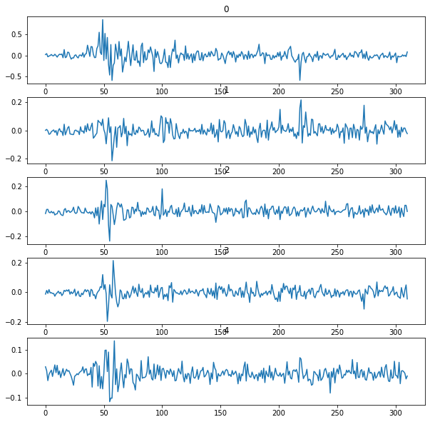

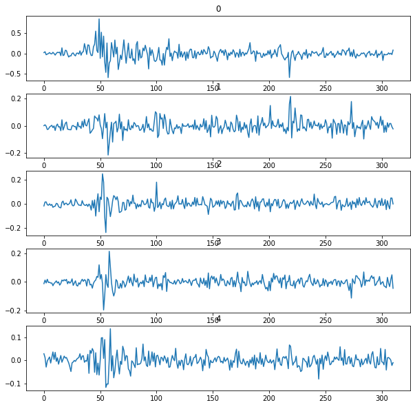

```python
model = create_var_model(df_of_principal_components_train)
model.plot()
```

```python
array_of_principal_components = pca.transform(df_stocks_returns)[:, :5]

var_model = VAR(df_of_principal_components_train)

# Lag order selection
lag_order = var_model.select_order()
lag_order.summary()
```

VAR Order Selection (* highlights the minimums)

|  | AIC | BIC | FPE | HQIC |
| --- | --- | --- | --- | --- |
| 0 | -30.18 | -30.12* | 7.787e-14 | -30.16* |
| 1 | -30.22 | -29.84 | 7.532e-14 | -30.07 |
| 2 | -30.33 | -29.64 | 6.734e-14 | -30.05 |
| 3 | -30.41 | -29.41 | 6.223e-14 | -30.01 |
| 4 | -30.42 | -29.11 | 6.136e-14 | -29.90 |
| 5 | -30.61 | -28.98 | 5.104e-14 | -29.96 |
| 6 | -30.64 | -28.71 | 4.930e-14 | -29.87 |
| 7 | -30.67 | -28.42 | 4.839e-14* | -29.76 |
| 8 | -30.67* | -28.11 | 4.845e-14 | -29.64 |
| 9 | -30.62 | -27.74 | 5.117e-14 | -29.47 |
| 10 | -30.60 | -27.41 | 5.240e-14 | -29.32 |
| 11 | -30.55 | -27.05 | 5.525e-14 | -29.15 |
| 12 | -30.45 | -26.64 | 6.145e-14 | -28.92 |
| 13 | -30.39 | -26.27 | 6.560e-14 | -28.74 |
| 14 | -30.33 | -25.89 | 7.055e-14 | -28.55 |
| 15 | -30.26 | -25.51 | 7.646e-14 | -28.36 |
| 16 | -30.23 | -25.17 | 7.985e-14 | -28.20 |

```python
lag_order_selected=lag_order.selected_orders['aic']
print('Number of lag selected : {}'.format(lag_order_selected))
```

```
Number of lag selected : 8
```

```python
var_model_results = var_model.fit(lag_order_selected)
```

### Forecast PC

```python
# Forcasting five futures pc
forecast_pc = var_model_results.forecast(df_of_principal_components_train.values[-lag_order_selected:],5)
pd.DataFrame(forecast_pc)
```

|  | 0 | 1 | 2 | 3 | 4 |
| --- | --- | --- | --- | --- | --- |
| 0 | 0.043542 | -0.004231 | -0.019285 | -0.001900 | 0.009345 |
| 1 | -0.029730 | -0.002410 | -0.002133 | 0.011927 | -0.010750 |
| 2 | -0.012551 | 0.007401 | 0.014477 | -0.004422 | -0.003738 |
| 3 | -0.008856 | 0.007598 | -0.007392 | -0.015060 | -0.001117 |
| 4 | -0.042018 | -0.023002 | -0.011844 | 0.008619 | -0.001850 |

### Inversing PCA

```python
# Compute the mean of the data set
mu = np.mean(df_stocks_returns_train, axis=0)
```

We have to re-had the mean to the new inverse PCA. In fact the PCA algorithm substract the mean so we had to give it back to the dataset.

$\boxed{\text{PCA reconstruction} = \text{PC scores} \cdot \text{Eigenvectors}^\top + \text{Mean}}$

```python
stocks_returns_estimators = np.dot(forecast_pc, pca.components_[:5,:])
stocks_returns_estimators += mu

print('The array of five forecast returns for each stocks is :\n')
pd.DataFrame(stocks_returns_estimators)
```

```
The array of five forecast returns for each stocks is :
```

|  | 0 | 1 | 2 | 3 | 4 | 5 | 6 | 7 | 8 | 9 | ... | 30 | 31 | 32 | 33 | 34 | 35 | 36 | 37 | 38 | 39 |
| --- | --- | --- | --- | --- | --- | --- | --- | --- | --- | --- | --- | --- | --- | --- | --- | --- | --- | --- | --- | --- | --- |
| 0 | -0.013415 | -0.002331 | -0.001970 | -0.002635 | -0.004783 | -0.002270 | -0.012709 | -0.004105 | -0.001588 | -0.009399 | ... | -0.000771 | -0.006446 | -0.012052 | -0.003897 | -0.003389 | 0.000149 | -0.010048 | -0.002876 | -0.003786 | -0.001641 |
| 1 | 0.008744 | 0.000500 | 0.009082 | 0.002840 | 0.004169 | -0.003149 | 0.008472 | -0.002139 | 0.005513 | 0.006035 | ... | -0.001284 | 0.007230 | 0.007075 | 0.007812 | 0.004049 | 0.001953 | -0.000703 | 0.000128 | 0.000321 | 0.008147 |
| 2 | 0.005434 | 0.001200 | -0.004299 | 0.000123 | 0.000315 | 0.000806 | 0.005223 | 0.003182 | 0.000352 | 0.003196 | ... | -0.000136 | 0.002974 | 0.003933 | 0.000889 | 0.001830 | 0.001008 | 0.006778 | 0.001092 | 0.002631 | -0.001640 |
| 3 | -0.000578 | 0.001541 | 0.000436 | 0.001609 | 0.001040 | 0.000137 | -0.001338 | -0.000209 | 0.004393 | 0.000762 | ... | 0.000021 | 0.001118 | 0.000358 | 0.004754 | 0.000927 | 0.005261 | 0.016734 | 0.002851 | 0.001877 | 0.003377 |
| 4 | 0.007016 | 0.005269 | 0.014570 | 0.006502 | 0.008527 | 0.000473 | 0.006844 | 0.000875 | 0.010512 | 0.007197 | ... | 0.003652 | 0.010697 | 0.006250 | 0.014469 | 0.009856 | 0.008641 | -0.008094 | 0.004878 | 0.003599 | 0.014670 |

5 rows × 40 columns

### Forecasting Price

```python
stocks_returns_estimators_p1 = stocks_returns_estimators + 1;
stocks_returns_estimators_cumprod = np.cumprod(stocks_returns_estimators_p1, axis = 0);
stocks_returns_estimators_cumprod;
last_prices_known = df_stocks_prices_train.loc['2021-03-19'].values.reshape(1,-1);
forcast_prices = last_prices_known * (stocks_returns_estimators_cumprod);
```

### Multiple Linear Regression

Now using the multiple regression we are going to give prediction for the CAC40 index.So we have the prediction for stocks on prices and on returns.

```python
# On prices
multiple_linear_reg_model_prices = LinearRegression()
multiple_linear_reg_model_prices.fit(df_stocks_prices_train, df_index_value_train)
cac40_index_forecast = multiple_linear_reg_model_prices.predict(forcast_prices)
pd.DataFrame(cac40_index_forecast)
pd.DataFrame(df_index_value_test);

# On returns
multiple_linear_reg_model_returns = LinearRegression()
multiple_linear_reg_model_returns.fit(df_stocks_returns_train, df_index_returns_train)
multiple_linear_reg_model_returns = LinearRegression()
multiple_linear_reg_model_returns.fit(df_stocks_returns_train, df_index_returns_train);

cac40_returns_forecast = multiple_linear_reg_model_returns.predict(stocks_returns_estimators)
pd.DataFrame(cac40_returns_forecast)

last_index_known = df_index_value.loc['2021-03-25'].reshape(1,-1)
cac40_returns_forecast_p1 = cac40_returns_forecast + 1
cac40_returns_forecast_cumprod = np.cumprod(cac40_returns_forecast_p1,axis=0)
forcast_index = last_index_known * (cac40_returns_forecast_p1);
```

#### Test on n days

In this section you are going to see our prediction during the last week of March. See right down som graphics.

```python
# Create CAC40 stocks dataFrames
last_date = '2021-03-29'
tickers_cac40_dict = tickers_cac40_dict_2
df_prices_returns = create_stocks_df(tickers_cac40_dict, last_date)
df_stocks_prices_ = df_prices_returns[0]
df_stocks_returns_ = df_prices_returns[1]

# Create CAC40 index dataFrames
df_index_value_ = df_stocks_prices_['^FCHI']
df_index_returns_ = df_stocks_returns_['^FCHI']

del df_stocks_prices_['^FCHI']
del df_stocks_returns_['^FCHI']

number_of_days_futur = 5
pred = make_predictions(number_of_days_futur,df_stocks_prices_, df_stocks_returns_, df_index_value_, df_index_returns_)

pred_based_on_prices = pred[0]
pred_based_on_returns = pred[1]
print(pred_based_on_prices)
print(pred_based_on_returns)
```

```
[*********************100%***********************]  41 of 41 completed
            ^FCHI Predictions Based on prices forecast
2021-03-29                                 6049.565492
2021-03-30                                 6104.903756
2021-03-31                                 6086.776343
2021-04-01                                 5970.038930
2021-04-02                                 5963.737285
            ^FCHI Predictions Based on returns forecast
2021-03-29                                  6066.901433
2021-03-30                                  6116.224489
2021-03-31                                  6089.995391
2021-04-01                                  5957.681916
2021-04-02                                  5966.612027
```

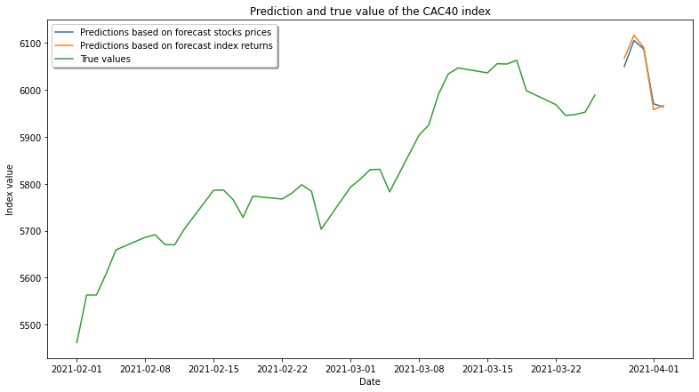

```python
# Plot
number_of_days_past=40
fig, ax = plt.subplots()
ax.plot(pred_based_on_prices.index, pred_based_on_prices.values, label='Predictions based on forecast stocks prices')
ax.plot(pred_based_on_returns.index, pred_based_on_returns.values, label='Predictions based on forecast index returns')
ax.plot(df_index_value_[-number_of_days_past:].index,df_index_value_[-number_of_days_past:].values, label='True values')
ax.legend(loc='best', shadow=True)
plt.title('Prediction and true value of the CAC40 index')
plt.xlabel('Date')
plt.ylabel('Index value')
plt.show()
```

#### Python module importation

```python
# Yahoo Finance for stock picking
import yfinance as yf

import numpy as np
import pandas as pd
import matplotlib.pyplot as plt
import os
import datetime

#For VAR section
import statsmodels.api as sm
from statsmodels.tsa.api import VAR
from statsmodels.tsa.stattools import adfuller, grangercausalitytests

# For PCA section
from numpy import linalg as LA
import sklearn
from sklearn import decomposition
from sklearn.linear_model import LinearRegression

from IPython.core.interactiveshell import InteractiveShell
InteractiveShell.ast_node_interactivity = "all"
```

#### Data processing function

```python
tickers_cac40_dict_2 = {
                        'Air Liquide': 'AI.PA', 'Airbus': 'AIR.PA',
                        'Alstom': 'ALO.PA', 'ArcelorMittal': 'MT.AS', 'Atos': 'ATO.PA',
                        'AXA': 'CS.PA', 'BNP Paribas': 'BNP.PA', 'Bouygues': 'EN.PA',
                        'Capgemini': 'CAP.PA', 'Carrefour': 'CA.PA', 'Crédit Agricole': 'ACA.PA',
                        'Danone': 'BN.PA', 'Dassault Systèmes': 'DSY.PA', 'Engie': 'ENGI.PA',
                        'EssilorLuxottica': 'EL.PA', 'Hermès': 'RMS.PA', 'Kering': 'KER.PA',
                        "L'Oréal": 'OR.PA', 'Legrand': 'LR.PA', 'LVMH': 'MC.PA',
                        'Michelin': 'ML.PA', 'Orange': 'ORA.PA', 'Pernod Ricard': 'RI.PA',
                        'Publicis': 'PUB.PA', 'Renault': 'RNO.PA', 'Safran': 'SAF.PA',
                        'Saint-Gobain': 'SGO.PA', 'Sanofi': 'SAN.PA', 'Schneider Electric': 'SU.PA',
                        'Société Générale': 'GLE.PA', 'Stellantis': 'STLA.PA',
                        'STMicroelectronics': 'STM.PA', 'Teleperformance': 'TEP.PA', 'Thales': 'HO.PA',
                        'Total': 'FP.PA', 'Unibail-Rodamco-Westfield': 'URW.AS', 'Veolia': 'VIE.PA',
                        'Vinci': 'DG.PA', 'Vivendi': 'VIV.PA', 'Worldline': 'WLN.PA',
                        'CAC40': '^FCHI'}

def create_stocks_df(dict_of_ticker, end_date="2021-03-28", ug_pa_file_name='ug.csv'):
    """
        Create and returns :
            a dataFrame containing all stocks and CAC40 value
            a dataFrame containing all stocks and CAC40 returns

    Parameters
    ----------
    dict_of_ticker : dict
        Dictionary containing key = Stock names, value=ticker..
    ug_pa_file_name : str
        Name of the file containing UG.PA data. The default is 'ug.csv'
    end_date : str, optional
        The date until we take data. Format : 'YYYY-MM-DD' The default is "2021-03-28".

    Returns
    -------
    data_value : pd.DataFrame
        Corresponds to a dataframe containing values at the close of the stocks for
        all dates of the selected period.
    data_returns : pd.DataFrame
        Corresponds to a dataframe containing returns at the close of the share for
        all dates of the selected period.

    """
    start_date = "2020-01-01"

    # Define the path of the UG.PA.csv file
    ug_pa_file_path = r"ug.csv"
    ug_value = pd.read_csv(ug_pa_file_path, sep=';', header=0, index_col='Date', parse_dates=True)

    # Define the ticker list base on the dictionary of tickers
    str_tickers = ""

    for key, value in dict_of_ticker.items():
        str_tickers += "{} ".format(value)

    # Take stocks value from yfinance
    data_value = yf.download(str_tickers, start=start_date, end=end_date)["Close"]

    # Define the history bound of UG.PA
    ug_index = ug_value.index
    first_ug_date = ug_index[0]
    last_ug_date = ug_index[-1]

    # Replace STLA.PA by the corresponding UG.PA value before the fusion of PSA and STLA
    data_value.loc[first_ug_date:last_ug_date, 'STLA.PA'] = ug_value['UG.PA']

    # Compute returns
    data_returns = data_value.pct_change()
    # Drop the first row fill off NaN cause by the returns computing
    data_returns = data_returns.drop(first_ug_date, axis='index')

    # Fill NaN by a linear interpolation along the columns
    data_returns = data_returns.interpolate(method='linear', axis=1)

    return data_value, data_returns
```

#### Functions for dimension reduction

```python
def select_component(pca_data, percent):
    """
    Params
    ------
        pca_data : pca dat
        percent : pourcent of explained variance

    Returns
    -------
        index : number of components such that we have the explained variance satisfied

    """
    index=0
    var = np.cumsum(np.round(pca_data.explained_variance_ratio_, decimals=3) * 100)
    while var[index]<percent :
        index+=1
    return index


# Plot explained variance in function of component
# Also plot a line of component we take into account
def plot_explained_var(pca_data, n):
    """
    Params
    ------
        pca_data : pca data
        n : number of component

    Returns
    -------
        plot of explained variance

    """
    variance = pca_data.explained_variance_ratio_  # calculate variance ratios
    var = np.cumsum(np.round(pca_data.explained_variance_ratio_, decimals=3) * 100)
    plt.ylabel('% Explained Variance')
    plt.xlabel('Number of Component')
    plt.title('PCA Analysis')
    plt.ylim(0, 102)
    plt.style.context('seaborn-whitegrid')
    plt.grid()
    plt.plot(var)
    plt.axvline(x=n, c='red', ls='--')
    plt.axhline(y=var[n], c='red', ls="--")
    plt.show()
```

```python
def marchenko_pastur_pdf1(l, Q):
    """
    Parameters
    ----------
    l : float
        Correspond to a float which will give us pdf(l)
    Q : float
        Corresponds to the

    Returns
    -------
    Value of the Marchenko Pastur Pdf evaluate in l

    """

    def m0(a):
        # Element wise maximum of (a,0)
        return np.maximum(a, np.zeros_like(a))

    l_plus = (1 + (1/Q) ** 0.5) ** 2
    l_min = (1 - (1/Q) ** 0.5) ** 2
    return Q * np.sqrt(m0(l_plus - l) * m0(l - l_min)) / (2 * np.pi * l)



def mp_pdf(Q, var, points):
    eMin, eMax = var*(1+np.sqrt(1/Q))**2, var*(1-np.sqrt(1/Q))**2
    eVal = np.linspace(eMin, eMax, points)
    pdf = Q / (2 * np.pi * var * eVal) * ((eMax - eVal) * (eVal - eMin)) ** .5
    pdf = pd.Series(pdf, index=eVal)
    return pdf
```

```python
def create_pca_model(data_set):
    # Compute the mean of the data set
    mu = np.mean(data_set, axis=0)

    # Create PCA
    pca = sklearn.decomposition.PCA()
    pca.fit(data_set)

    nb_components = select_component(pca, 95)

    array_of_principal_components = pd.DataFrame(pca.transform(data_set)[:, :nb_components])

    return array_of_principal_components,pca, nb_components, mu
```

```python
def inverse_pca(forecast_pc,pca,nb_components,mu):
    data_reconstructed = np.dot(forecast_pc, pca.components_[:nb_components,:])
    data_reconstructed += mu
    return data_reconstructed
```

#### VAR Model function

```python
def create_var_model(data):
    var_model = VAR(data)
    results = var_model.fit(ic='aic')
    # lag_order = results.k_ar
    # print('lag order : {}'.format(lag_order))
    return results

def forecasting_pc(var_model,data_set,nb_of_predictions=1):
    lag_order = var_model.k_ar
    forecast_pc = var_model.forecast(data_set.values[-lag_order-nb_of_predictions+1:],nb_of_predictions)
    return forecast_pc
```

#### Multiple regression model

```python
def create_linear_model(x_training_set,y_training_set):
    multiple_linear_reg_model = LinearRegression()
    multiple_linear_reg_model.fit(x_training_set, y_training_set)
    return multiple_linear_reg_model
```

#### Prediction function

```python
def make_predictions(nb_of_days_futur, data_stocks_prices, data_stocks_returns, data_index_value, data_index_returns):

    df_index_forecast_based_on_prices_forecast = pd.DataFrame(columns = ['^FCHI Predictions Based on prices forecast'])
    df_index_forecast_based_on_prices_forecast.index = pd.DatetimeIndex(df_index_forecast_based_on_prices_forecast.index)

    df_index_forecast_based_on_returns_forecast = pd.DataFrame(columns = ['^FCHI Predictions Based on returns forecast'])
    df_index_forecast_based_on_returns_forecast.index = pd.DatetimeIndex(df_index_forecast_based_on_returns_forecast.index)


    date_past = data_stocks_prices.index[-1]
    df_stocks_prices = data_stocks_prices[:date_past]
    df_stocks_returns = data_stocks_returns[:date_past]
    df_index_value = data_index_value[:date_past]
    df_index_returns = data_index_returns[:date_past]

    pca_model = create_pca_model(df_stocks_returns)

    df_of_principal_components = pca_model[0]

    var_model = create_var_model(df_of_principal_components)

    # Forcasting PC
    forecast_pc = forecasting_pc(var_model, df_of_principal_components,nb_of_days_futur)

    # Reconstruct all components
    stocks_returns_estimators = inverse_pca(forecast_pc, pca_model[1], pca_model[2], pca_model[3])

    #Forecasting prices
    stocks_returns_estimators_p1 = stocks_returns_estimators + 1
    stocks_returns_estimators_cumprod = stocks_returns_estimators_p1

    last_prices_known = df_stocks_prices.loc[date_past,:].values.reshape(1,-1)
    forecast_prices = last_prices_known * stocks_returns_estimators_cumprod


    # Forecasting CAC40 index based on :
    # - Forecast prices
    ml_model_prices = create_linear_model(df_stocks_prices, df_index_value)
    index_forecast_based_on_prices_forecast = ml_model_prices.predict(forecast_prices)

    # - Forecast returns
    ml_model_returns = create_linear_model(df_stocks_returns, df_index_returns)
    index_returns_estimators = ml_model_returns.predict(stocks_returns_estimators)
    index_returns_estimators_p1 = 1 + index_returns_estimators
    index_returns_estimators_cumprod = index_returns_estimators_p1

    last_index_value_known = df_index_value.loc[df_stocks_prices.index[-1]]
    index_forecast_based_on_returns_forecast = last_index_value_known * index_returns_estimators_cumprod



    futures_date = date_past
    #If the futures_date is in the weekend

    for i in range(len(index_forecast_based_on_prices_forecast)):
        futures_date += datetime.timedelta(days=1)
        while futures_date.weekday() >=5:
            futures_date += datetime.timedelta(days=1)

        df_index_forecast_based_on_prices_forecast.loc[futures_date]=index_forecast_based_on_prices_forecast[i]

        df_index_forecast_based_on_returns_forecast.loc[futures_date]=index_forecast_based_on_returns_forecast[i]

    return df_index_forecast_based_on_prices_forecast,df_index_forecast_based_on_returns_forecast
```